# Assignment-Basic-statistics-2

1. Look at the data given below. Plot the data, find the outliers and find out μ,σ,σ^2 Name of company Measure X

Allied Signal 24.23%

Bankers Trust 25.53%

General Mills 25.41%

Industries 24.14%

J.P.Morgan & Co. 29.62%

Lehman Brothers 28.25%

Marriott 25.81%

MCI 24.39%

Merrill Lynch 40.26%

Microsoft 32.95%

Morgan Stanley 91.36%

Sun Microsystems 25.99%

Travelers 39.42%

US Airways 26.71%

Warner-Lambert 35.00%

```python
from scipy import stats
import numpy as np
import statistics as st
import pandas as pd
import matplotlib.pyplot as plt
import math
```

```python
Df_1=pd.DataFrame({'Company':['Allied Signal',
'Bankers Trust',
'General Mills',
'ITT Industries',
'J.P.Morgan & Co',
'Lehman Brothers',
'Marriott',
'MCI',
'Merrill Lynch',
'Microsoft',
'Morgan Stanley',
'Sun Microsystems',
'Travelers',
'US Airways',
'Warner-Lambert'],'Measurex':[24.23,25.53,25.41,24.14,29.62,28.25,25.81,24.39,40.26,32.95,91.36,25.99,39.42,26.71,35.00]})
Df_1
#measure_X=pd.Series([24.23,25.53,25.41,24.14,29.62,28.25,25.81,24.39,40.26,32.95,91.36,25.99,39.42,26.71,35.00])
#measure_X
```

|  | Company | Measurex |
| --- | --- | --- |
| 0 | Allied Signal | 24.23 |
| 1 | Bankers Trust | 25.53 |
| 2 | General Mills | 25.41 |
| 3 | ITT Industries | 24.14 |
| 4 | J.P.Morgan & Co | 29.62 |
| 5 | Lehman Brothers | 28.25 |
| 6 | Marriott | 25.81 |
| 7 | MCI | 24.39 |
| 8 | Merrill Lynch | 40.26 |
| 9 | Microsoft | 32.95 |
| 10 | Morgan Stanley | 91.36 |
| 11 | Sun Microsystems | 25.99 |
| 12 | Travelers | 39.42 |
| 13 | US Airways | 26.71 |
| 14 | Warner-Lambert | 35.00 |

```python
Mean1=Df_1['Measurex'].mean()
Variance1=Df_1['Measurex'].var()
STD1=Df_1['Measurex'].std()
print("The Mean is:",Mean1,"The Variance is:",Variance1,"The standard Deviation is:",STD1)
```

```
The Mean is: 33.27133333333333 The Variance is: 287.1466123809524 The standard Deviation is: 16.945400921222028
```

[output not shown]

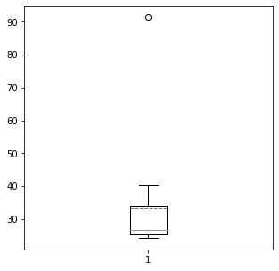

```python
#Plot the graph
plt.figure(figsize=(5,5))
plt.boxplot(Df_1['Measurex'],meanline=True,showmeans=True,data=True)
#xlabel:("Company",Size=10)
#ylabel:("Measure of X",Size=10)
```

```python
#To find the outliers
Q_1=np.quantile(Df_1["Measurex"],0.25)
Q_3=np.quantile(Df_1["Measurex"],0.75)
Interquartile=Q_3-Q_1
print(Interquartile)
```

```
8.505000000000003
```

```python
lowerlimit=Q_1-1.5*Interquartile
Higherlimit=Q_3+1.5*Interquartile
```

```python
Lower_outlier=[]
Higher_outlier=[]
for i in Df_1['Measurex']:
  if Higherlimit:
     Higher_outlier=i
print("Lower outlier is",Lower_outlier)
print("Higher outlier is",Higher_outlier)
```

```
Lower outlier is []
Higher outlier is 35.0
```

2.)

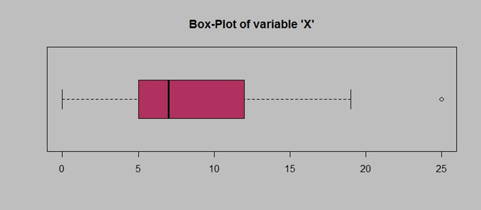

Answer the following three questions based on the box-plot above.

(i) What is inter-quartile range of this dataset? (please approximate the numbers) In one line, explain what this value implies.

(ii) What can we say about the skewness of this dataset?

(iii) If it was found that the data point with the value 25 is actually 2.5, how would the new box-plot be affected?

Ans:

(i) IQR=Q3-Q1=12-5=7 Interquartile range is the difference of 3rd and 1st quartiles in a dataset. (Dispersion of Data

(ii) Skewness of this Data is Right skewed because the Data concentrated more in left side so RHS will be Skewed.

(iii)The median will reduce and Interquartile range will be more into LHS of graph Than RHS due to the less value 2.5 added with dataset. Median shifted to left side

3.)

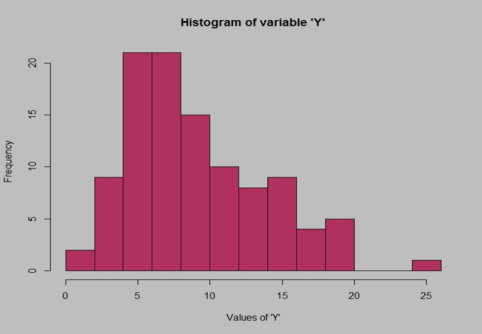

Answer the following three questions based on the histogram above.

(i) Where would the mode of this dataset lie?

(ii) Comment on the skewness of the dataset.

(iii) Suppose that the above histogram and the box-plot in question 2 are plotted for the same dataset. Explain how these graphs complement each other in providing information about any dataset.

Ans:

(i) (Between 4 and 8)

(ii)Its Right skewed because the maximum frequency came on LHS of the graph and mode and mean in LHS.

(iii)Both Data set shows its Right Skewed and more data are concentrated in LHS and maximum data are CONCENTRATED in LHS. So, the IQR of box plot and the datasets or graph in Histogram also shown in LHS shift. And there is one outlier in RHS shown both in Boxplot and Histogram. But from Histogram we will get exact information about frequency value which not value wise shown in Boxplot. But the median shown in Box plot that we can’t get Exact value easily from Histogram.

4.AT&T was running commercials in 1990 aimed at luring back customers who had switched to one of the other long-distance phone service providers. One such commercial shows a businessman trying to reach Phoenix and mistakenly getting Fiji, where a half-naked native on a beach responds incomprehensibly in Polynesian. When asked about this advertisement, AT&T admitted that the portrayed incident did not actually take place but added that this was an enactment of something that “could happen.” Suppose that one in 200 long-distance telephone calls is misdirected. What is the probability that at least one in five attempted telephone calls reaches the wrong number? (Assume independence of attempts.)

```python
# What is the probability that at least one in five attempted telephone calls reaches the wrong number?
(1/5)*(1/200)
```

```
0.001
```

5.

Returns on a certain business venture, to the nearest $1,000, are known to follow the following probability distribution x P(x) -2,000 0.1 -1,000 0.1 0 0.2 1000 0.2 2000 0.3 3000 0.1

(i) What is the most likely monetary outcome of the business venture?

(ii) Is the venture likely to be successful? Explain

(iii) What is the long-term average earning of business ventures of this kind? Explain

(iv) What is the good measure of the risk involved in a venture of this kind? Compute this measure

```python
#cREATING THE DATAFRAME
Df_5=pd.DataFrame({'x':['-2000','-1000','0','1000','2000','3000'],'PX':[0.1,0.1,0.2,0.2,0.3,0.1]})
```

```python
Df_5
```

|  | x | PX |
| --- | --- | --- |
| 0 | -2000 | 0.1 |
| 1 | -1000 | 0.1 |
| 2 | 0 | 0.2 |
| 3 | 1000 | 0.2 |
| 4 | 2000 | 0.3 |
| 5 | 3000 | 0.1 |

```python
#(i)	What is the most likely monetary outcome of the business venture?

max5=Df_5['PX'].max()
Most_likely_monetary_outcome=Df_5[Df_5['PX']==max5]

Most_likely_monetary_outcome
```

|  | x | PX |
| --- | --- | --- |
| 4 | 2000 | 0.3 |

```python
#(ii)Is the venture likely to be successful? Explain
#VENTURE WILL BE SUCCES IF X POSITIVE
Success=Df_5[Df_5['x']>'0']
total_success=0
for i in Success['PX']:
  total_success=total_success+float(i)
if total_success>0.5:
  print("venture likely to be successful;",total_success,'>0.5')
else:
  print("venture not likely to be successful;",total_success,'<0.5')
```

```
venture likely to be successful; 0.6 >0.5
```

```python
#(iii)What is the long-term average earning of business ventures of this kind? Explain
#E(X)=SUM(x.P(x))
Df_5=Df_5.astype(float)
EX=Df_5.product(axis=1).sum()
EX
```

```
800.0
```

```python
#(iv)	What is the good measure of the risk involved in a venture of this kind? Compute this measure
#variance=E(x^2)-E(x)^2
k1=Df_5.loc[:,'x']
k2=Df_5.loc[:,'PX']
T=k1*k1*k2
Var=T.sum()-(EX)**2
Var
STD=math.sqrt(Var)
STD
```

```
1469.6938456699068
```

```python
#STD is 1469.694 so its very high Hence the stock is in risky.
```